# R Notebook

### Datei einlesen

```r
ChickWeight <- read.csv("C:/Users/alfa/Downloads/Statistik/ChickWeight.csv")
View(ChickWeight)
```

#### Prüfung der Daten

```r
head(ChickWeight)
```

|  | X | weight | Time | Chick | Diet |
| --- | --- | --- | --- | --- | --- |
| 1 | 1 | 42 | 0 | 1 | 1 |
| 2 | 2 | 51 | 2 | 1 | 1 |
| 3 | 3 | 59 | 4 | 1 | 1 |
| 4 | 4 | 64 | 6 | 1 | 1 |
| 5 | 5 | 76 | 8 | 1 | 1 |
| 6 | 6 | 93 | 10 | 1 | 1 |

```r
str(ChickWeight,give.attr =F )
```

```
'data.frame':   578 obs. of  5 variables:
 $ X     : int  1 2 3 4 5 6 7 8 9 10 ...
 $ weight: int  42 51 59 64 76 93 106 125 149 171 ...
 $ Time  : int  0 2 4 6 8 10 12 14 16 18 ...
 $ Chick : int  1 1 1 1 1 1 1 1 1 1 ...
 $ Diet  : int  1 1 1 1 1 1 1 1 1 1 ...
```

### Gibt es Missing Values?

```r
sum(is.na(ChickWeight))
```

```
[1] 0
```

```r
sprintf("Anzahl der NAs: %d",sum(is.na(ChickWeight)) )
```

```
[1] "Anzahl der NAs: 0"
```

```r
#unique(ChickWeight$weight)
```

```r
library(ggplot2)
library(dplyr)
library(psych)
library(car)
library(effsize)
library(lsr)
library(sjstats)
library(ez)
```

**Zeitliche Achse**

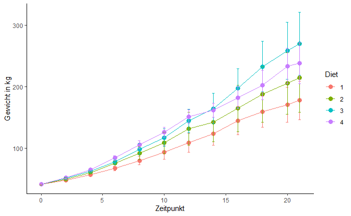

```r
ChickWeight$Diet <-as.factor(ChickWeight$Diet)
ggplot(ChickWeight, aes(x=Time , y=weight, group=Diet, color=Diet ))+
stat_summary(fun = mean, geom="point", size=3)+
stat_summary(fun = mean, geom="line")+
stat_summary(fun.data = mean_cl_normal, geom="errorbar",width=.2, size=.25)+
labs(x="Zeitpunkt", y="Gewicht in kg")+
theme_classic()
```

```r
Gewicht <- ChickWeight$weight*0.028
ChickWeight["Gewicht"] <- Gewicht
View(ChickWeight)
```

subset / filtern

```r
ChickWeight_sub <- subset(ChickWeight , Time == 8 | Time == 16 | Time == 21 )
View(ChickWeight_sub)
```

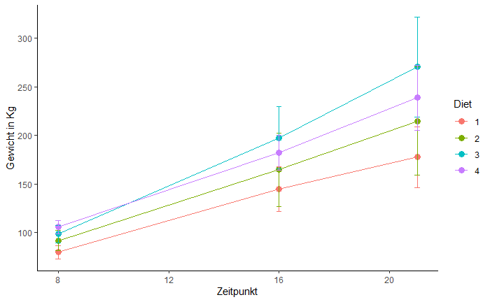

```r
ChickWeight_sub$Diet <-as.factor(ChickWeight_sub$Diet)
library(ggplot2)
ggplot(ChickWeight_sub, aes(x=Time , y=weight, group=Diet , color= Diet))+
stat_summary(fun = mean, geom="point", size=3)+
stat_summary(fun = mean, geom="line")+
stat_summary(fun.data = mean_cl_normal, geom="errorbar",width=.2, size=.25)+
labs(x="Zeitpunkt", y="Gewicht in Kg")+
theme_classic()
```

```r
interaktion=paste(ChickWeight_sub$Time, ChickWeight_sub$Diet, sep=".")

ChickWeight_sub["interaktion"] <- interaktion
```

### 1) Hypothese

Haupteffekt A = Time H0:Es gibt keinen Unterschied zwischen den verschiedenen Messzeitpunkten und dem Gewicht des Tieres. H1:Es gibt einen Unterschied zwischen den verschiedenen Messzeitpunkten und dem Gewicht des Tieres.

Haupteffekt B = Diet H0:Es gibt keinen Unterschied zwischen der Ernährung und dem Gewicht des Tieres. H1:Es gibt einen Unterschied zwischen der Ernährung und dem Gewicht des Tieres.

Interaktion AxB = (Time x Diet) H1: Es gibt einen Unterschied in der Interaktion zwischen Ernährung und den verschiedenen Messzeitpunkten in punkto Gewicht. H0: Es gibt keinen Unterschied in der Interaktion zwischen Ernährung und den verschiedenen Messzeitpunkten in punkto Gewicht.

### 2) Voraussetzungen der einfaktoriellen Varianzanalyse mit Messwiederholung

✓ Die abhängige Variable ist min. intervallskaliert -> Gewicht ist ratioskaliert und somti metrisch.

✓ Die unabhängige Variable (Faktor) ist kategorial (nominal- oder ordinalskaliert) - Ja, es wird der Unterschied zwischen vier Diäten betrachtet.

✓ Die abhängige Variable ist normalverteilt innerhalb jedes Messzeitpunktes (Ab > 25 Probanden pro Messzeitpunkt sind Verletzungen in der Regel unproblematisch) -> Hisogramm und QQplot

✓ Es liegen min. drei verbundene Stichproben oder Gruppen vor, aber die verschiedenen Messwertpaare sind voneinander unabhängig s -> ist gegeben

✓ Die durch den Faktor gebildeten Gruppen sind unabhängig s -> ist gegeben

### 3) Deskriptive Statistik

```r
psych::describe(ChickWeight_sub)
```

|  | vars | n | mean | sd | median | trimmed | mad | min | max | range | skew | kurtosis | se |
| --- | --- | --- | --- | --- | --- | --- | --- | --- | --- | --- | --- | --- | --- |
| X | 1 | 141 | 293.69 | 167.82 | 297.00 | 294.19 | 214.98 | 5.0 | 578.00 | 573.00 | -0.03 | -1.22 | 14.13 |
| weight | 2 | 141 | 157.53 | 72.10 | 147.00 | 150.05 | 75.61 | 57.0 | 373.00 | 316.00 | 0.76 | -0.19 | 6.07 |
| Time | 3 | 141 | 14.82 | 5.39 | 16.00 | 14.89 | 7.41 | 8.0 | 21.00 | 13.00 | -0.22 | -1.55 | 0.45 |
| Chick | 4 | 141 | 25.94 | 14.64 | 27.00 | 26.04 | 19.27 | 1.0 | 50.00 | 49.00 | -0.08 | -1.23 | 1.23 |
| Diet* | 5 | 141 | 2.26 | 1.16 | 2.00 | 2.19 | 1.48 | 1.0 | 4.00 | 3.00 | 0.29 | -1.41 | 0.10 |
| Gewicht | 6 | 141 | 4.41 | 2.02 | 4.12 | 4.20 | 2.12 | 1.6 | 10.44 | 8.85 | 0.76 | -0.19 | 0.17 |
| interaktion* | 7 | 141 | 6.31 | 3.49 | 6.00 | 6.30 | 4.45 | 1.0 | 12.00 | 11.00 | -0.01 | -1.24 | 0.29 |

```r
psych::describeBy(ChickWeight_sub$Gewicht, group = ChickWeight_sub$Time, mat = T)
```

|  | item | group1 | vars | n | mean | sd | median | trimmed | mad | min | max | range | skew | kurtosis | se |
| --- | --- | --- | --- | --- | --- | --- | --- | --- | --- | --- | --- | --- | --- | --- | --- |
| X11 | 1 | 8 | 1 | 49 | 2.554857 | 0.4547138 | 2.520 | 2.545951 | 0.4566408 | 1.596 | 3.668 | 2.072 | 0.09731452 | -0.272471768 | 0.06495912 |
| X12 | 2 | 16 | 1 | 47 | 4.706383 | 1.3133142 | 4.732 | 4.696821 | 1.1623584 | 1.988 | 8.036 | 6.048 | 0.12711358 | -0.008743709 | 0.19156657 |
| X13 | 3 | 21 | 1 | 45 | 6.123289 | 2.0022877 | 5.740 | 6.121405 | 2.1171528 | 2.072 | 10.444 | 8.372 | 0.08910638 | -0.768096703 | 0.29848342 |

```r
psych::describeBy(ChickWeight_sub$Gewicht, group = ChickWeight_sub$Diet, mat = T)
```

|  | item | group1 | vars | n | mean | sd | median | trimmed | mad | min | max | range | skew | kurtosis | se |
| --- | --- | --- | --- | --- | --- | --- | --- | --- | --- | --- | --- | --- | --- | --- | --- |
| X11 | 1 | 1 | 1 | 52 | 3.670692 | 1.643583 | 3.150 | 3.505333 | 1.639756 | 1.596 | 8.540 | 6.944 | 0.8488661 | -0.03410886 | 0.2279239 |
| X12 | 2 | 2 | 1 | 30 | 4.396933 | 2.070427 | 4.046 | 4.181333 | 2.179422 | 1.848 | 9.268 | 7.420 | 0.7203893 | -0.51917867 | 0.3780065 |
| X13 | 3 | 3 | 1 | 30 | 5.283600 | 2.407025 | 4.872 | 5.100667 | 2.905896 | 2.240 | 10.444 | 8.204 | 0.4571585 | -1.04727240 | 0.4394606 |
| X14 | 4 | 4 | 1 | 29 | 4.849793 | 1.726788 | 4.900 | 4.728640 | 1.951102 | 2.744 | 9.016 | 6.272 | 0.4171135 | -0.69803300 | 0.3206565 |

```r
psych::describeBy(ChickWeight_sub$Gewicht, group = ChickWeight_sub$interaktion, mat = T)
```

|  | item | group1 | vars | n | mean | sd | median | trimmed | mad | min | max | range | skew | kurtosis | se |
| --- | --- | --- | --- | --- | --- | --- | --- | --- | --- | --- | --- | --- | --- | --- | --- |
| X11 | 1 | 16.1 | 1 | 17 | 4.050118 | 1.2610473 | 4.172 | 4.033867 | 1.4944608 | 1.988 | 6.356 | 4.368 | 0.22422389 | -1.0988621 | 0.30584889 |
| X12 | 2 | 16.2 | 1 | 10 | 4.611600 | 1.4790934 | 4.396 | 4.550000 | 1.1000892 | 2.016 | 7.700 | 5.684 | 0.36116238 | -0.1081377 | 0.46773039 |
| X13 | 3 | 16.3 | 1 | 10 | 5.527200 | 1.2482404 | 5.460 | 5.432000 | 1.0585764 | 3.780 | 8.036 | 4.256 | 0.45927983 | -0.7775117 | 0.39472828 |
| X14 | 4 | 16.4 | 1 | 10 | 5.096000 | 0.7084732 | 5.026 | 5.085500 | 0.8717688 | 4.060 | 6.216 | 2.156 | -0.04411303 | -1.4027447 | 0.22403889 |
| X15 | 5 | 21.1 | 1 | 16 | 4.977000 | 1.6436580 | 4.648 | 4.886000 | 1.6812684 | 2.688 | 8.540 | 5.852 | 0.44532534 | -0.6857374 | 0.41091451 |
| X16 | 6 | 21.2 | 1 | 10 | 6.011600 | 2.1878675 | 5.950 | 6.097000 | 2.0341272 | 2.072 | 9.268 | 7.196 | -0.13544583 | -1.1554203 | 0.69186446 |
| X17 | 7 | 21.3 | 1 | 10 | 7.568400 | 2.0054312 | 7.868 | 7.640500 | 2.0756400 | 4.116 | 10.444 | 6.328 | -0.31972000 | -1.2724984 | 0.63417304 |
| X18 | 8 | 21.4 | 1 | 9 | 6.679556 | 1.2137371 | 6.636 | 6.679556 | 1.3699224 | 5.488 | 9.016 | 3.528 | 0.62822524 | -1.1014155 | 0.40457904 |
| X19 | 9 | 8.1 | 1 | 19 | 2.231158 | 0.3857335 | 2.212 | 2.215294 | 0.2905896 | 1.596 | 3.136 | 1.540 | 0.52788479 | -0.3330610 | 0.08849334 |
| X110 | 10 | 8.2 | 1 | 10 | 2.567600 | 0.4144778 | 2.520 | 2.541000 | 0.1245384 | 1.848 | 3.500 | 1.652 | 0.63287857 | 0.4992515 | 0.13106938 |

[output cut: 2 more lines]

```r
mittel <-tapply(ChickWeight_sub$Gewicht, list(ChickWeight_sub$Diet, ChickWeight_sub$Time), mean, na.rm=TRUE)
mittel
```

```
         8       16       21
1 2.231158 4.050118 4.977000
2 2.567600 4.611600 6.011600
3 2.755200 5.527200 7.568400
4 2.956800 5.096000 6.679556
```

```r
sd <-tapply(ChickWeight_sub$Gewicht, list(ChickWeight_sub$Diet, ChickWeight_sub$Time), sd, na.rm=TRUE)
sd
```

```
          8        16       21
1 0.3857335 1.2610473 1.643658
2 0.4144778 1.4790934 2.187868
3 0.3457619 1.2482404 2.005431
4 0.2614000 0.7084732 1.213737
```

```r
mittel <-tapply(ChickWeight_sub$Gewicht, list(ChickWeight_sub$Diet, ChickWeight_sub$Time), mean, na.rm=TRUE)
mittel
```

```
         8       16       21
1 2.231158 4.050118 4.977000
2 2.567600 4.611600 6.011600
3 2.755200 5.527200 7.568400
4 2.956800 5.096000 6.679556
```

```r
sd <-tapply(ChickWeight_sub$Gewicht, list(ChickWeight_sub$Diet, ChickWeight_sub$Time), sd, na.rm=TRUE)
sd
```

```
          8        16       21
1 0.3857335 1.2610473 1.643658
2 0.4144778 1.4790934 2.187868
3 0.3457619 1.2482404 2.005431
4 0.2614000 0.7084732 1.213737
```

```r
anzahlprogruppe <- tapply(ChickWeight_sub$Gewicht, list(ChickWeight_sub$Diet, ChickWeight_sub$Time), function(x) sum(!is.na(x)))
anzahlprogruppe
```

```
   8 16 21
1 19 17 16
2 10 10 10
3 10 10 10
4 10 10  9
```

### 4) Voraussetzungsprüfung

### 4.1) Normalverteilung der Daten mithilfe des Histogrammes

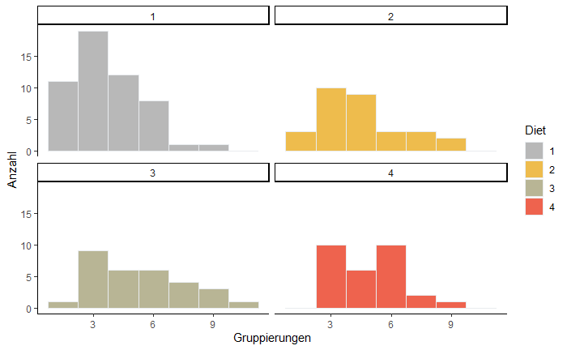

```r
library(ggpubr)
library(cowplot)

p1 = ggplot(ChickWeight_sub, aes(x=Gewicht, color=Diet, fill=Diet)) +
geom_histogram( binwidth=1.5, aes(fill=Diet), color="#e9ecef", alpha=0.7) + # Erstelle ein Histogramm, Unterteilung, Farbe + Transparenz
facet_wrap(~Diet)+ # Zwei Graphen
theme_classic()+ #Farbschema
labs(x="Gruppierungen", y="Anzahl") + # Beschriftung
scale_color_manual(values=c("#999999", "#E69F00","#999567", "#E61F01"))+
scale_fill_manual(values=c("#999999", "#E69F00", "#999567", "#E61F01"))
p1
```

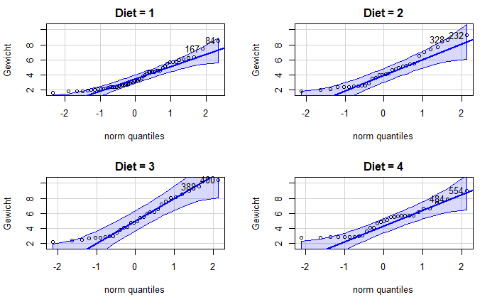

```r
p2 = qqPlot(Gewicht ~ Diet, data=ChickWeight_sub,
layout=c(2, 2))
```

```r
p2
```

[figure not shown]

```r
plot_grid(p1, p2, labels = "AUTO")
```

Die Ernaehrung ist schief

**Time**

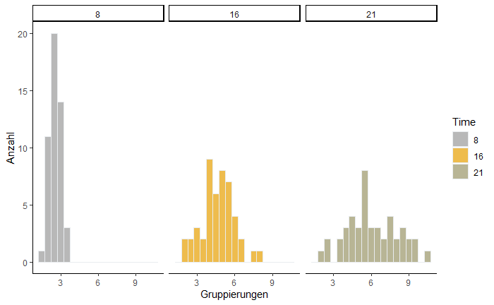

```r
ChickWeight_sub$Time <- as.factor(ChickWeight_sub$Time)
p1 =ggplot(ChickWeight_sub, aes(x=Gewicht, color=Time, fill=Time)) +
geom_histogram( binwidth=0.5, aes(fill=Time), color="#e9ecef", alpha=0.7) + # Erstelle ein Histogramm, Unterteilung, Farbe + Transparenz
facet_wrap(~Time)+ # Zwei Graphen
theme_classic()+ #Farbschema
labs(x="Gruppierungen", y="Anzahl") + # Beschriftung
scale_color_manual(values=c("#999999", "#E69F00","#999567", "#E61F01"))+
scale_fill_manual(values=c("#999999", "#E69F00", "#999567", "#E61F01"))
p1
```

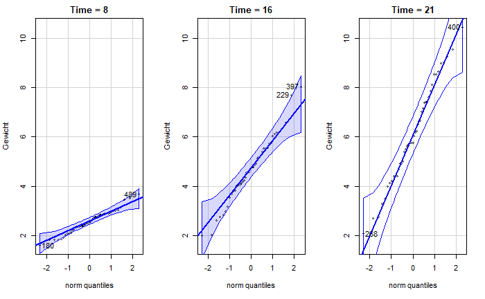

```r
p2 = qqPlot(Gewicht ~ Time, data=ChickWeight_sub,
layout=c(1, 3))
```

```r
p2
```

[figure not shown]

```r
plot_grid(p1, p2, labels = "AUTO")
```

**Diet**

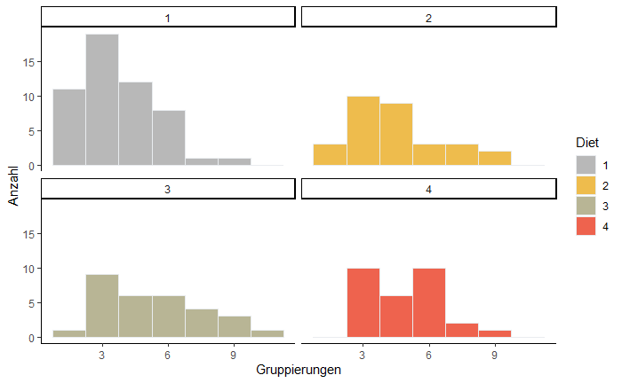

```r
library(car)
library(ggpubr)
library(cowplot)

p1 = ggplot(ChickWeight_sub, aes(x=Gewicht, color=Diet, fill=Diet)) +
geom_histogram( binwidth=1.5, aes(fill=Diet), color="#e9ecef", alpha=0.7) + # Erstelle ein Histogramm, Unterteilung, Farbe + Transparenz
facet_wrap(~Diet)+ # Zwei Graphen
theme_classic()+ #Farbschema
labs(x="Gruppierungen", y="Anzahl") + # Beschriftung
scale_color_manual(values=c("#999999", "#E69F00","#999567", "#E61F01"))+
scale_fill_manual(values=c("#999999", "#E69F00", "#999567", "#E61F01"))
p1
```

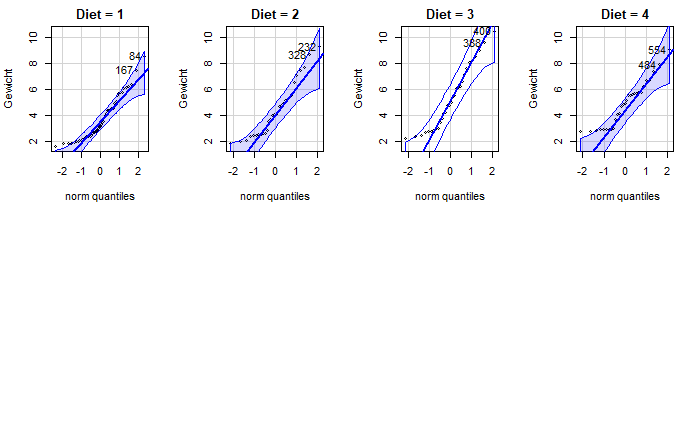

```r
p2 = qqPlot(Gewicht ~ Diet, data=ChickWeight_sub,
layout=c(2, 4))
```

```r
p2
```

[figure not shown]

```r
plot_grid(p1, p2, labels = "AUTO")
```

**Interaktion**

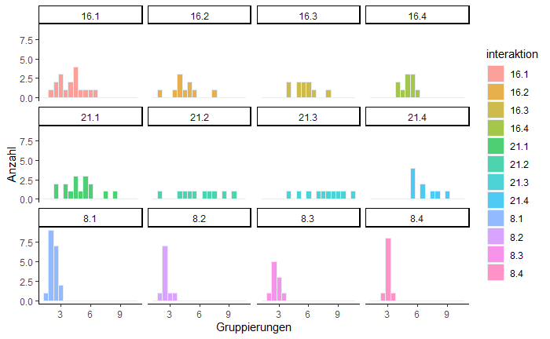

```r
ChickWeight_sub$interaktion <- as.factor(ChickWeight_sub$interaktion)
p1 =ggplot(ChickWeight_sub, aes(x=Gewicht, color=interaktion, fill=interaktion)) +
geom_histogram( binwidth=0.5, aes(fill=interaktion), color="#e9ecef", alpha=0.7) + # Erstelle ein Histogramm, Unterteilung, Farbe + Transparenz
facet_wrap(~interaktion)+ # Zwei Graphen
theme_classic()+ #Farbschema
labs(x="Gruppierungen", y="Anzahl") # Beschriftung

p1
```

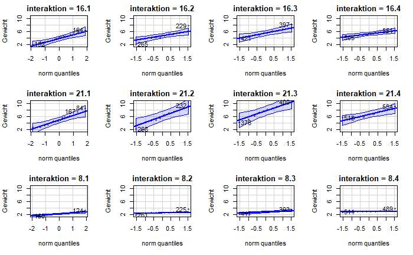

```r
p2 = qqPlot(Gewicht ~ interaktion, data=ChickWeight_sub,
layout=c(3, 4))
```

```r
p2
```

[figure not shown]

```r
plot_grid(p1, p2, labels = "AUTO")
```

#### Boxplot

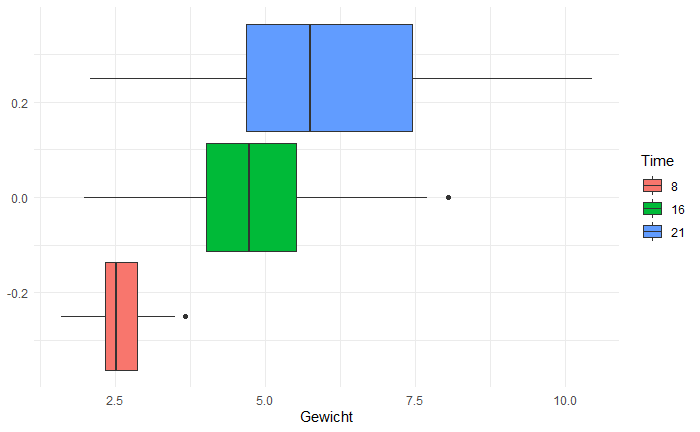

```r
ggplot(ChickWeight_sub, aes(Gewicht, fill=factor(Time))) +
geom_boxplot() +
theme_minimal()+
labs(fill = "Time", x="Gewicht")
```

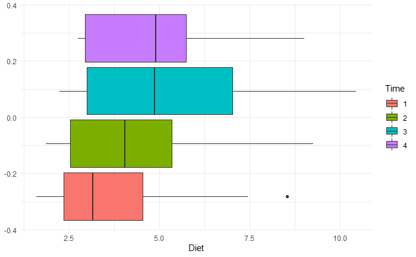

```r
ggplot(ChickWeight_sub, aes(Gewicht, fill=factor(Diet))) +
geom_boxplot() +
theme_minimal()+
labs(fill = "Time", x="Diet")
```

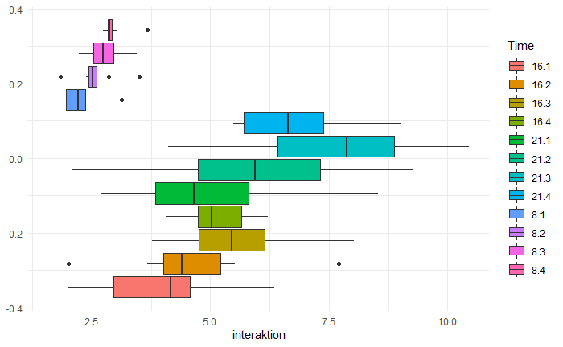

```r
ggplot(ChickWeight_sub, aes(Gewicht, fill=factor(interaktion))) +
geom_boxplot() +
theme_minimal()+
labs(fill = "Time", x="interaktion")
```

[figure not shown]

```r
library(htmltools)

ggplot(ChickWeight_sub,
aes(x=Time,
y=Gewicht,
group = Diet,
color = Diet,
aesthetics = "fill"
)
)+
stat_summary(fun = mean,
geom="point",
size=3
)+
stat_summary(fun = mean,
geom="line",
size= 1.5
)+
stat_summary(fun.data = mean_cl_normal,
geom="errorbar",
width=0.2,
size=1
)+
stat_summary(aes(label=round(..y..,2)),
fun ='mean',
geom="text",
size=4,
position = position_nudge(x = -0.25, y = 0.75)
)+
labs(title = "Die Zeit in Abhängigkeit von der Ernährung",
x="Ernährung",
y="Gesundheitsindex")+
theme(panel.background = element_rect(size = 0.5, fill = "gray91", colour = "black", linetype='solid'),
panel.grid.major = element_line(size = 0.5, linetype = 'solid', colour = "darkgray"),
panel.grid.minor = element_line(size = 0.5, linetype = 'solid', colour = "gray"),
)
```

### 4.3) Prüfung der Varianzhomogenität (Levene-Test)

```r
leveneTest(ChickWeight_sub$Gewicht ~ ChickWeight_sub$Diet, center = "mean")
```

```
Levene's Test for Homogeneity of Variance (center = "mean")
       Df F value  Pr(>F)
group   3  2.7543 0.04494 *
      137
---
Signif. codes:  0 ‘***’ 0.001 ‘**’ 0.01 ‘*’ 0.05 ‘.’ 0.1 ‘ ’ 1
```

```r
leveneTest(ChickWeight_sub$Gewicht ~ ChickWeight_sub$Time, center = "mean")
```

```
Levene's Test for Homogeneity of Variance (center = "mean")
       Df F value    Pr(>F)
group   2  28.516 4.308e-11 ***
      138
---
Signif. codes:  0 ‘***’ 0.001 ‘**’ 0.01 ‘*’ 0.05 ‘.’ 0.1 ‘ ’ 1
```

```r
leveneTest(ChickWeight_sub$Gewicht ~ ChickWeight_sub$interaktion, center = "mean")
```

```
Levene's Test for Homogeneity of Variance (center = "mean")
       Df F value    Pr(>F)
group  11  6.6438 9.966e-09 ***
      129
---
Signif. codes:  0 ‘***’ 0.001 ‘**’ 0.01 ‘*’ 0.05 ‘.’ 0.1 ‘ ’ 1
```

### 4.4) Balanciertheit des Designs

```r
anzahlprogruppe <- tapply(ChickWeight_sub$Gewicht, list(ChickWeight_sub$Diet, ChickWeight_sub$Time), function(x) sum(!is.na(x)))
anzahlprogruppe
```

```
   8 16 21
1 19 17 16
2 10 10 10
3 10 10 10
4 10 10  9
```

### 5) Profildiagramm

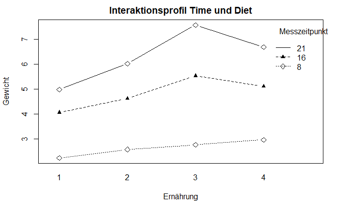

```r
interaction.plot(ChickWeight_sub$Diet,ChickWeight_sub$Time, ChickWeight_sub$Gewicht,
xlab = "Ernährung", ylab = "Gewicht",
main = "Interaktionsprofil Time und Diet",
trace.label = "Messzeitpunkt",
type = "b", pch = c(5,17))
```

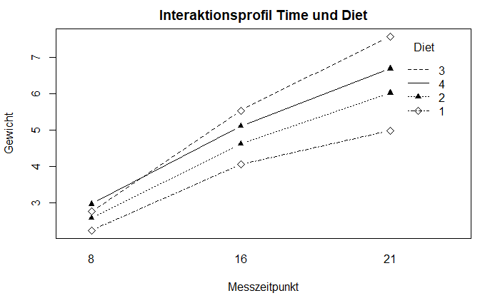

```r
interaction.plot(ChickWeight_sub$Time,ChickWeight_sub$Diet, ChickWeight_sub$Gewicht,
xlab = "Messzeitpunkt", ylab = "Gewicht",
main = "Interaktionsprofil Time und Diet",
trace.label = "Diet",
type = "b", pch = c(5,17))
```

```r
pairwise.t.test(ChickWeight_sub$Gewicht, ChickWeight_sub$Diet, data=ChickWeight_sub, p.adjust.method = "bonf", paired = F)
```

```
    Pairwise comparisons using t tests with pooled SD

data:  ChickWeight_sub$Gewicht and ChickWeight_sub$Diet

  1      2      3
2 0.6248 -      -
3 0.0024 0.4701 -
4 0.0575 1.0000 1.0000

P value adjustment method: bonferroni
```

```r
pairwise.t.test(ChickWeight_sub$Gewicht, ChickWeight_sub$Time, data=ChickWeight_sub, p.adjust.method = "bonf", paired = F)
```

```
    Pairwise comparisons using t tests with pooled SD

data:  ChickWeight_sub$Gewicht and ChickWeight_sub$Time

   8       16
16 1.3e-11 -
21 < 2e-16 8.1e-06

P value adjustment method: bonferroni
```

```r
pairwise.t.test(ChickWeight_sub$Gewicht, ChickWeight_sub$interaktion, data=ChickWeight_sub, p.adjust.method = "bonf", paired = F)
```

```
    Pairwise comparisons using t tests with pooled SD

data:  ChickWeight_sub$Gewicht and ChickWeight_sub$interaktion

     16.1    16.2    16.3    16.4    21.1    21.2    21.3    21.4    8.1     8.2     8.3
16.2 1.00000 -       -       -       -       -       -       -       -       -       -
16.3 0.23593 1.00000 -       -       -       -       -       -       -       -       -
16.4 1.00000 1.00000 1.00000 -       -       -       -       -       -       -       -
21.1 1.00000 1.00000 1.00000 1.00000 -       -       -       -       -       -       -
21.2 0.00872 0.88608 1.00000 1.00000 1.00000 -       -       -       -       -       -
21.3 5.8e-09 3.3e-05 0.02462 0.00133 6.3e-05 0.40351 -       -       -       -       -
21.4 7.5e-05 0.02944 1.00000 0.43726 0.09042 1.00000 1.00000 -       -       -       -
8.1  0.00172 0.00020 2.9e-08 2.3e-06 1.2e-07 1.6e-10 < 2e-16 4.9e-13 -       -       -
8.2  0.22821 0.02419 3.2e-05 0.00089 0.00030 5.5e-07 2.1e-13 3.5e-09 1.00000 -       -
8.3  0.68340 0.07624 0.00014 0.00337 0.00140 2.8e-06 1.4e-12 1.9e-08 1.00000 1.00000 -
8.4  1.00000 0.23946 0.00065 0.01312 0.00667 1.5e-05 1.0e-11 1.1e-07 1.00000 1.00000 1.00000

P value adjustment method: bonferroni
```